# Matplotlib 基础

在使用**Numpy**之前，需要了解一些画图的基础。

**Matplotlib**是一个类似**Matlab**的工具包，主页地址为

http://matplotlib.org

导入 `matplotlib` 和 `numpy`：

```python
%pylab
```

```
Using matplotlib backend: Qt4Agg
```

## plot 二维图

```
plot(y)
plot(x, y)
plot(x, y, format_string)
```

只给定 `y` 值，默认以下标为 `x` 轴：

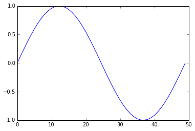

```python
%matplotlib inline
x = linspace(0, 2 * pi, 50)
plot(sin(x))
```

给定 `x` 和 `y` 值：

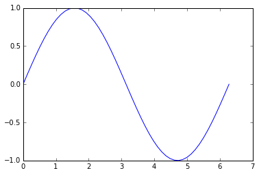

```python
plot(x, sin(x))
```

多条数据线：

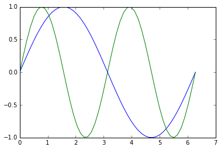

```python
plot(x, sin(x),
    x, sin(2 * x))
```

使用字符串，给定线条参数：

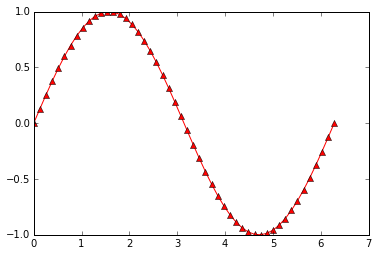

```python
plot(x, sin(x), 'r-^')
```

多线条：

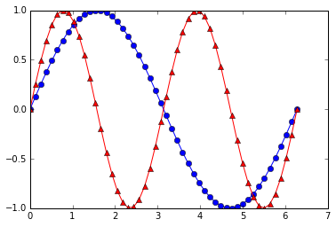

```python
plot(x, sin(x), 'b-o',
    x, sin(2 * x), 'r-^')
```

更多参数设置，请查阅帮助。事实上，字符串使用的格式与**Matlab**相同。

## scatter 散点图

```
scatter(x, y)
scatter(x, y, size)
scatter(x, y, size, color)
```

假设我们想画二维散点图：

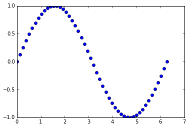

```python
plot(x, sin(x), 'bo')
```

可以使用 `scatter` 达到同样的效果：

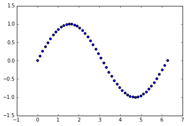

```python
scatter(x, sin(x))
```

事实上，scatter函数与**Matlab**的用法相同，还可以指定它的大小，颜色等参数：

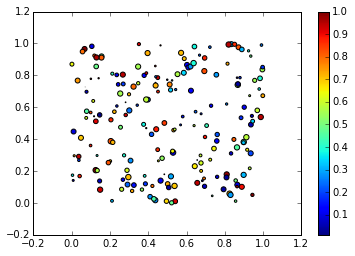

```python
x = rand(200)
y = rand(200)
size = rand(200) * 30
color = rand(200)
scatter(x, y, size, color)
# 显示颜色条
colorbar()
```

## 多图

使用figure()命令产生新的图像：

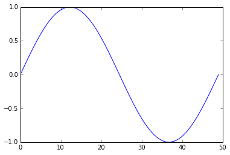

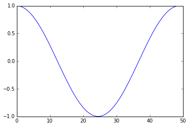

```python
t = linspace(0, 2*pi, 50)
x = sin(t)
y = cos(t)
figure()
plot(x)
figure()
plot(y)
```

或者使用 `subplot` 在一幅图中画多幅子图：

```
subplot(row, column, index)
```

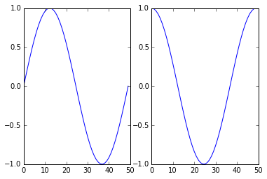

```python
subplot(1, 2, 1)
plot(x)
subplot(1, 2, 2)
plot(y)
```

## 向图中添加数据

默认多次 `plot` 会叠加：

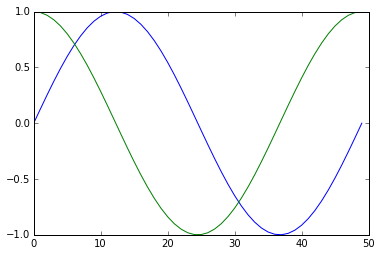

```python
plot(x)
plot(y)
```

可以跟**Matlab**类似用 hold(False)关掉，这样新图会将原图覆盖：

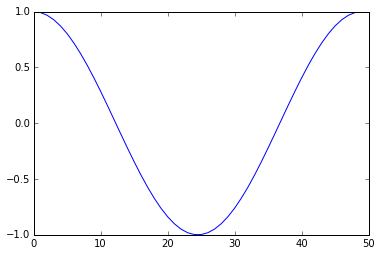

```python
plot(x)
hold(False)
plot(y)
# 恢复原来设定
hold(True)
```

## 标签

可以在 `plot` 中加入 `label` ，使用 `legend` 加上图例：

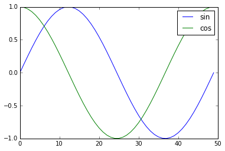

```python
plot(x, label='sin')
plot(y, label='cos')
legend()
```

或者直接在 `legend`中加入：

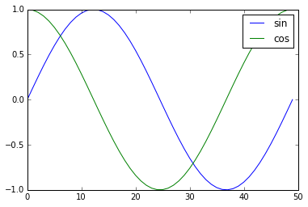

```python
plot(x)
plot(y)
legend(['sin', 'cos'])
```

## 坐标轴，标题，网格

可以设置坐标轴的标签和标题：

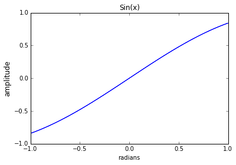

```python
plot(x, sin(x))
xlabel('radians')
# 可以设置字体大小
ylabel('amplitude', fontsize='large')
title('Sin(x)')
```

用 'grid()' 来显示网格：

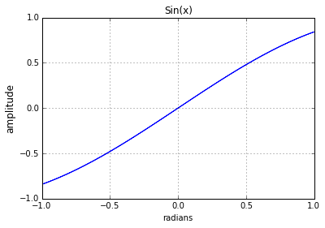

```python
plot(x, sin(x))
xlabel('radians')
ylabel('amplitude', fontsize='large')
title('Sin(x)')
grid()
```

## 清除、关闭图像

清除已有的图像使用：

```
clf()
```

关闭当前图像：

```
close()
```

关闭所有图像：

```
close('all')
```

## imshow 显示图片

灰度图片可以看成二维数组：

```python
# 导入lena图片
from scipy.misc import lena
img = lena()
img
```

```
array([[162, 162, 162, ..., 170, 155, 128],
       [162, 162, 162, ..., 170, 155, 128],
       [162, 162, 162, ..., 170, 155, 128],
       ...,
       [ 43,  43,  50, ..., 104, 100,  98],
       [ 44,  44,  55, ..., 104, 105, 108],
       [ 44,  44,  55, ..., 104, 105, 108]])
```

我们可以用 `imshow()` 来显示图片数据：

[figure not shown]

```python
imshow(img,
       # 设置坐标范围
      extent = [-25, 25, -25, 25],
       # 设置colormap
      cmap = cm.bone)
colorbar()
```

更多参数和用法可以参阅帮助。

这里 `cm` 表示 `colormap`，可以看它的种类：

```python
dir(cm)
```

```
[u'Accent',
 u'Accent_r',
 u'Blues',
 u'Blues_r',
 u'BrBG',
 u'BrBG_r',
 u'BuGn',
 u'BuGn_r',
 u'BuPu',
 u'BuPu_r',
 u'CMRmap',
 u'CMRmap_r',
 u'Dark2',
 u'Dark2_r',
 u'GnBu',
 u'GnBu_r',
 u'Greens',
 u'Greens_r',
 u'Greys',
 u'Greys_r',
 'LUTSIZE',
 u'OrRd',
 u'OrRd_r',
 u'Oranges',
 u'Oranges_r',
 u'PRGn',
 u'PRGn_r',
 u'Paired',
 u'Paired_r',
 u'Pastel1',
 u'Pastel1_r',
 u'Pastel2',
 u'Pastel2_r',
 u'PiYG',
 u'PiYG_r',
 u'PuBu',
 u'PuBuGn',
 u'PuBuGn_r',
 u'PuBu_r',
 u'PuOr',
```

[output cut: 118 more lines]

```
 u'seismic_r',
 'six',
 'spec',
 'spec_reversed',
 u'spectral',
 u'spectral_r',
 u'spring',
 u'spring_r',
 u'summer',
 u'summer_r',
 u'terrain',
 u'terrain_r',
 'unicode_literals',
 u'winter',
 u'winter_r']
```

使用不同的 `colormap` 会有不同的显示效果。

[figure not shown]

```python
imshow(img, cmap=cm.RdGy_r)
```

## 从脚本中运行

在脚本中使用 `plot` 时，通常图像是不会直接显示的，需要增加 `show()` 选项，只有在遇到 `show()` 命令之后，图像才会显示。

## 直方图

从高斯分布随机生成1000个点得到的直方图：

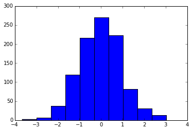

```python
hist(randn(1000))
```

更多例子请参考下列网站：

http://matplotlib.org/gallery.html